# Is the reference point visible in choices without attention? (exploratory)

Brenden Eum

2026-11-07

Exploratory notebook. Nothing here is in the paper.

**Question.** In the Bayesian model the prior mean $m_0$ is the reference point. Does anything in the choices tell us where $m_0$ is if we do not know how long each attribute was looked at? The algebra below says no (when there is no loss aversion). This notebook checks that with the project’s own likelihood and asks how much of the information about the reference point comes from attention, and from which part of attention.

What this notebook does **not** do: it fits no new model. It only evaluates the existing likelihood (`code/simulation/simulate_bayesian_attributes.R`, `code/fitting/fit_bayesian_attributes.R`) at a grid of reference points, with the dwell times left alone or changed in one of three ways. With $\lambda = 1$ the probit is the exact choice probability, so there is no approximation here.

Sections:

1. The algebra
2. Setup
3. Four versions of the dwell data
4. Likelihood over the reference point, $\lambda = 1$
5. Results
6. With loss aversion ($\lambda = 1.06$), does the kink identify the reference?
7. Side result: how much of the box-level dwell does the model want?
8. Notes

# 1. The algebra

Box $j$ has true value $a_j$ and was looked at for $t_j$ seconds. Its estimate is $m_j = m_0 + \pi_j(\bar{x}_j - m_0)$, where $\pi_j = \pi(t_j)$ is the relative precision of the sample and $\bar{x}_j \sim \mathcal{N}(a_j, \sigma_x^2/t_j)$. With $\lambda = 1$ the utility of a box is its estimate, and an option’s utility is the sum of its two boxes. Left minus right:

$$\Delta \;=\; \sum_{j \in L} \pi_j \bar{x}_j \;-\; \sum_{j \in R} \pi_j
\bar{x}_j \;-\; m_0\,(\Pi_L - \Pi_R),
\qquad \Pi_L = \sum_{j \in L} \pi_j, \quad \Pi_R = \sum_{j \in R} \pi_j
.$$

(Each option has two boxes, so the $2 m_0$ terms cancel.) The prior mean enters only through $\Pi_L - \Pi_R$: how much more precision the left option received than the right option. The variance of $\Delta$ does not contain $m_0$ at all.

So if all four boxes of a trial are looked at for the same time, $\Pi_L = \Pi_R$, $m_0$ drops out, and the choice probability does not depend on $q$. Attention that differs between the options is the only thing that lets the choices say where the reference point is.

# 2. Setup

```r
library(tidyverse)

# Project utilities: paths, the plot theme (.myPlot), colors, build_pas() / build_boxlong().
source(here::here("code/utilities/getAllUtilities.R"))
```

```r
data_dir   <- file.path(paths$root, paths$data$processed)
cache_dir  <- file.path(paths$root, paths$results$cache, "bayesian_model")
nb_fig_dir <- file.path(paths$root, paths$notebooks, "notebook_figures")
dir.create(nb_fig_dir, showWarnings = FALSE, recursive = TRUE)
```

```r
# Same data as the other notebooks: one row per box (option x attribute) with its value and dwell time.
pas     <- build_pas(read_csv(file.path(data_dir, "main_data.csv"), show_col_types = FALSE))
boxlong <- build_boxlong(pas)
```

```r
# The model and the fitting code (the main model is the variant cond_lam).
source(here::here("code/simulation/simulate_bayesian_attributes.R"))
source(here::here("code/fitting/fit_bayesian_attributes.R"))

variants <- bayesian_variants()
prep     <- prepare_boxes(boxlong, variants$cond_lam)   # trials with a never-hovered box are dropped here
conds    <- names(prep$cond)                              # "Narrow" "Wide"

# The cached full fit of the main model, only to mark its q on the figures.
main_fit <- readRDS(file.path(cache_dir, "fit_cond_lam.rds"))
cat("Main model: q =", round(main_fit$q, 3), " lambda =", round(main_fit$lambda[[1]], 3), "\n")
```

```
## Main model: q = 0.217 0.187  lambda = 1.063
```

```r
cat(nrow(prep$all$trials), "trials,", nrow(prep$subjects), "subjects\n")
```

```
## 58122 trials, 1506 subjects
```

# 3. Four versions of the dwell data

The likelihood reads each box’s dwell time from the subject pieces (`prep$subj`). I make three copies of `prep` in which the dwell times are changed, and keep the original:

```r
change_dwell <- function(prep, version, seed = 1) {
  set.seed(seed)
  # Loop over subjects and replace the dwell column of that subject's boxes.
  for (s in names(prep$subj)) {
    b <- prep$subj[[s]]$boxes
    if (version == "equal") {
      b$dwell <- ave(b$dwell, b$trial_id)                          # mean over the four boxes of the trial
    } else if (version == "option") {
      b$dwell <- ave(b$dwell, b$trial_id, b$side_sign)             # mean over the two boxes of the same option
    } else if (version == "shuffled") {
      b$dwell <- ave(b$dwell, b$trial_id, FUN = function(x) x[sample.int(length(x))])   # random order within the trial
    }
    prep$subj[[s]]$boxes <- b
  }
  prep
}

versions <- c("real", "equal", "option", "shuffled")
preps <- list()
for (v in versions) preps[[v]] <- change_dwell(prep, v)
```

A check that the versions do what they say. Per trial: total dwell, and how much more the left option was looked at than the right option (absolute difference, in seconds).

```r
check <- tibble()
for (v in versions) {
  b <- bind_rows(lapply(preps[[v]]$subj, function(p) p$boxes))
  per_trial <- b %>%
    group_by(Subject, Trial) %>%
    summarise(total = sum(dwell),
              asym  = abs(sum(dwell[side_sign == 1]) - sum(dwell[side_sign == -1])),
              .groups = "drop")
  check <- bind_rows(check, tibble(version = v,
                                   mean_total_dwell = mean(per_trial$total),
                                   mean_abs_left_minus_right = mean(per_trial$asym)))
}
check %>% mutate(across(where(is.numeric), ~ round(.x, 3)))
```

```
## # A tibble: 4 × 3
##   version  mean_total_dwell mean_abs_left_minus_right
##   <chr>               <dbl>                     <dbl>
## 1 real                 6.91                      1.50
## 2 equal                6.91                      0
## 3 option               6.91                      1.50
## 4 shuffled             6.91                      1.26
```

# 4. Likelihood over the reference point, $\lambda = 1$

For each version, I move $q$ over a grid (the same $q$ in both range conditions; the two conditions are independent given $q$, so each has its own curve). At every $q$ the population of sampling noise $(\mu, \tau)$ is re-fitted by `profile_cond()`, exactly as in Stage 1 of the paper’s fitting procedure. The numbers are negative log-likelihoods (lower is better).

```r
q_grid       <- seq(-0.2, 0.8, by = 0.05)
profile_file <- file.path(cache_dir, "attention_identifies_reference_lambda1.rds")

if (file.exists(profile_file)) {
  profile <- readRDS(profile_file)
} else {
  profile <- tibble()
  for (v in versions) {
    for (q in q_grid) {
      par <- new_par(conds, s0_fixed_of(prep$variant), q, 1)    # lambda = 1, so the probit is exact
      ll  <- grid_pass(preps[[v]], par)                          # every subject's log-likelihood on the sigma grid
      for (cc in conds) {
        pop     <- profile_cond(preps[[v]], cc, par, NULL, ll)   # best (mu, tau) of this condition at this q
        profile <- bind_rows(profile, tibble(version = v, q = q, cond = cc, nll = pop$nll))
      }
    }
  }
  saveRDS(profile, profile_file)
}
profile$version <- factor(profile$version, levels = versions)
```

# 5. Results

```r
summary_rows <- tibble()
for (v in versions) {
  for (cc in conds) {
    d    <- profile %>% filter(version == v, cond == cc)
    best <- d %>% slice_min(nll, n = 1, with_ties = FALSE)
    at0  <- d %>% filter(abs(q - 0.5) < 1e-9)                    # q = 0.5 puts the reference at 0 (the zero prior)
    summary_rows <- bind_rows(summary_rows, tibble(
      version              = v,
      condition            = cc,
      best_q_on_grid       = best$q,
      nll_at_best          = best$nll,
      range_over_q_grid    = max(d$nll) - min(d$nll),             # how far the likelihood moves over q in [-0.2, 0.8]
      cost_of_zero_prior   = at0$nll - best$nll                   # NLL at q = 0.5 minus the best NLL
    ))
  }
}
summary_rows %>% mutate(across(where(is.numeric), ~ round(.x, 3)))
```

```
## # A tibble: 8 × 6
##   version  condition best_q_on_grid nll_at_best range_over_q_grid
##   <chr>    <chr>              <dbl>       <dbl>             <dbl>
## 1 real     Narrow              0.25      15197.              710.
## 2 real     Wide                0.2       14693.              809.
## 3 equal    Narrow              0.1       15423.                0
## 4 equal    Wide               -0.2       14961.                0
## 5 option   Narrow              0.15      15098.              881.
## 6 option   Wide                0.15      14604.              998.
## 7 shuffled Narrow              0.5       15536.              827.
## 8 shuffled Wide                0.5       15081.              888.
## # ℹ 1 more variable: cost_of_zero_prior <dbl>
```

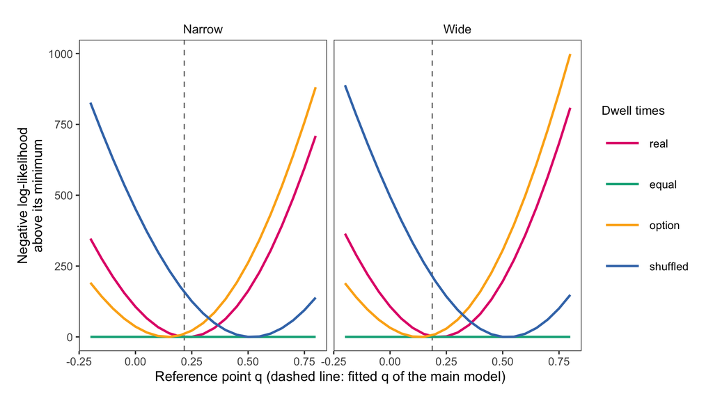

```r
# Each curve is shifted so that its own minimum is 0: the height of a curve is
# what is lost by putting the reference at the wrong place.
plot_data <- profile %>%
  group_by(version, cond) %>%
  mutate(delta_nll = nll - min(nll)) %>%
  ungroup()

fitted_q <- tibble(cond = names(main_fit$q), q = unname(main_fit$q))

p <- ggplot(plot_data, aes(q, delta_nll, color = version)) +
  geom_vline(data = fitted_q, aes(xintercept = q), linetype = "dashed", color = "grey50") +
  geom_line(linewidth = 0.9) +
  facet_wrap(~ cond) +
  scale_color_manual(values = c(real = "#E20778", equal = "#09AD87", option = "#FCAF17", shuffled = "#3E77B7"),
                     name = "Dwell times") +
  labs(x = "Reference point q (dashed line: fitted q of the main model)",
       y = "Negative log-likelihood\nabove its minimum") +
  .myPlot +
  # .myPlot is sized for the paper's figures; smaller text for this notebook figure
  theme(text = element_text(size = 11), axis.title = element_text(size = 11),
        axis.text = element_text(size = 9), legend.title = element_text(size = 10),
        legend.text = element_text(size = 9), legend.position = "right",
        strip.text = element_text(size = 10), strip.background = element_blank())
p
```

```r
ggsave(file.path(nb_fig_dir, "attention_identifies_reference.pdf"), p, width = 8, height = 3.6)
```

# 6. With loss aversion ($\lambda = 1.06$), does the kink identify the reference?

With $\lambda \neq 1$ the utility has a kink at $m_0$, so the reference point gets a second footprint that does not need attention. The question is how large it is at the fitted loss aversion. The exact likelihood is needed here (the grid calculation in C++), so this is slower; the result is cached. Only the real and the equal versions, at three values of $q$.

```r
kink_file <- file.path(cache_dir, "attention_identifies_reference_kink.rds")
lam_fit   <- main_fit$lambda[[1]]
q_kink    <- c(0.0, 0.2, 0.4)

if (file.exists(kink_file)) {
  kink <- readRDS(kink_file)
} else {
  kink <- tibble()
  for (v in c("real", "equal")) {
    for (q in q_kink) {
      par <- new_par(conds, s0_fixed_of(prep$variant), q, lam_fit)
      ll  <- grid_pass(preps[[v]], par, exact = TRUE)
      for (cc in conds) {
        pop  <- profile_cond(preps[[v]], cc, par, NULL, ll)
        kink <- bind_rows(kink, tibble(version = v, q = q, cond = cc, nll = pop$nll))
      }
    }
  }
  saveRDS(kink, kink_file)
}

kink %>%
  group_by(version, cond) %>%
  mutate(delta_nll = nll - min(nll)) %>%
  ungroup() %>%
  mutate(across(where(is.numeric), ~ round(.x, 3)))
```

```
## # A tibble: 12 × 5
##    version     q cond      nll delta_nll
##    <chr>   <dbl> <chr>   <dbl>     <dbl>
##  1 real      0   Narrow 15298.    120.
##  2 real      0   Wide   14798.     99.2
##  3 real      0.2 Narrow 15178.      0
##  4 real      0.2 Wide   14699.      0
##  5 real      0.4 Narrow 15285.    107.
##  6 real      0.4 Wide   14823.    124.
##  7 equal     0   Narrow 15419.      9.77
##  8 equal     0   Wide   14960.      0
##  9 equal     0.2 Narrow 15410.      0
## 10 equal     0.2 Wide   14971.     11.7
## 11 equal     0.4 Narrow 15452.     42.8
## 12 equal     0.4 Wide   15015.     55.1
```

# 7. Side result: how much of the box-level dwell does the model want?

In section 5 the “option” version (both boxes of an option get the option’s mean dwell) has a *lower* negative log-likelihood than the real dwell times. That is a statement about the main model, not about identification, so I checked it before trusting it. The blend below moves from the “option” version ($a = 0$) to the real dwell times ($a = 1$):
$$t'_j = a \, t_j + (1 - a)
\, \bar{t}_{\text{option}(j)} .$$
At every $a$ the reference point is re-optimised separately in each range condition (a bounded one-dimensional search, as in Stage 2 of the fitting). $\lambda = 1$, so the probit is exact. (Values of $a$ above 1 would exaggerate the within-option differences but give some boxes negative dwell, so they are not used.)

```r
blend_dwell <- function(prep, a) {
  for (s in names(prep$subj)) {
    b       <- prep$subj[[s]]$boxes
    opt     <- ave(b$dwell, b$trial_id, b$side_sign)     # mean dwell of the box's option
    b$dwell <- a * b$dwell + (1 - a) * opt
    prep$subj[[s]]$boxes <- b
  }
  prep
}

blend_file <- file.path(cache_dir, "attention_identifies_reference_blend.rds")
a_grid     <- c(0, 0.25, 0.5, 0.75, 1)     # a > 1 would give some boxes negative dwell

if (file.exists(blend_file)) {
  blend <- readRDS(blend_file)
} else {
  blend <- tibble()
  for (a in a_grid) {
    pa <- blend_dwell(prep, a)
    for (cc in conds) {
      subs <- pa$subjects$Subject[pa$subjects$WN == cc]
      # negative log-likelihood of this condition as a function of q
      f <- function(q) {
        par <- new_par(conds, s0_fixed_of(prep$variant), q, 1)
        ll  <- grid_pass(pa, par, subjects = subs)
        profile_cond(pa, cc, par, NULL, ll)$nll
      }
      opt   <- optimize(f, interval = c(-0.2, 0.6))
      blend <- bind_rows(blend, tibble(a = a, cond = cc, best_q = opt$minimum, nll = opt$objective))
    }
  }
  saveRDS(blend, blend_file)
}

blend %>%
  pivot_wider(names_from = cond, values_from = c(best_q, nll)) %>%
  mutate(across(where(is.numeric), ~ round(.x, 3)))
```

```
## # A tibble: 5 × 5
##       a best_q_Narrow best_q_Wide nll_Narrow nll_Wide
##   <dbl>         <dbl>       <dbl>      <dbl>    <dbl>
## 1  0            0.143       0.131     15098.   14604.
## 2  0.25         0.145       0.134     15083.   14589.
## 3  0.5          0.15        0.139     15080.   14585.
## 4  0.75         0.164       0.153     15096.   14602.
## 5  1            0.23        0.219     15197.   14692.
```

# 8. Notes

Numbers are from the render of 2026-11-07 (they are in the tables above).